# Delineamento de Experimentos

Efeito de agrotóxicos na produção de laranjas - Análise

Jonatha Azevedo/Leonardo Filgueira

24 de abril de 2018

## Descrição das variáveis medidas no objeto de estudo

**variável resposta**: Peso total das laranjas (em Kg) por pé.

**Fator**: Grupo de utilização de agrotóxico

**Níveis**:

- 1 = sem agrotóxico
- 2 = com metade da dose atualmente aplicada
- 3 = com a dose atualmente aplicada

## Análise

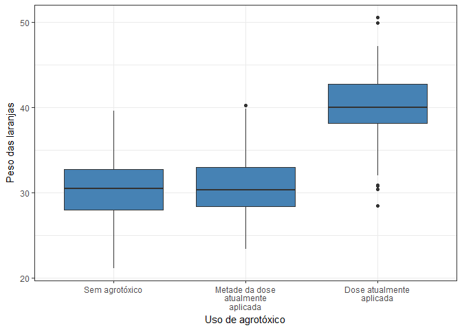

```r
base %>%
  mutate(ind = factor(ind,
                      labels = c("Sem agrotóxico", "Metade da dose atualmente aplicada",
                                 "Dose atualmente aplicada"))) %>%
  ggplot(aes(x = ind, y = pesos)) +
  geom_boxplot(fill = "steelblue") +
  theme_bw() +
  labs(x = "Uso de agrotóxico", y = "Peso das laranjas") +
  scale_x_discrete(labels = function(x) str_wrap(x, width = 15))
```

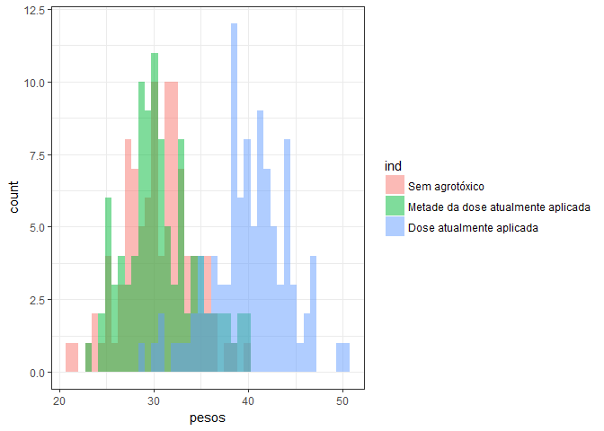

```r
base %>%
  mutate(ind = factor(ind,
                      labels = c("Sem agrotóxico", "Metade da dose atualmente aplicada",
                                 "Dose atualmente aplicada"))) %>%
  ggplot(aes(x = pesos, fill = ind)) +
  geom_histogram(binwidth=.7, alpha=0.5, position="identity") +
  theme_bw()
```

Para os testes aplicados em seguida, utilizamos um nível de significância estatística de 5%.

#### Tese para detectar normalidade (Shapiro)

O teste de shapiro, teste para normalidade, considera as seguintes hipóteses:

1. Formulação da Hipótese:

$$\begin{cases}
H_{0}: \mbox{A amostra provém de uma população Normal} \\
H_{1}: \mbox{A amostra não provém de uma população Normal}
\end{cases}$$

Primeiro para o tratamento **sem agrotóxicos** (*nível 1*):

```r
base %>%
  filter(ind == 1) %>%
  pull(pesos) %>%
  shapiro.test()
```

```
##
##  Shapiro-Wilk normality test
##
## data:  .
## W = 0.9956, p-value = 0.9876
```

Com o p-valor de `0.988` não rejeitamos a hipótese de normalidade dos dados para o tratamento do nível 1.

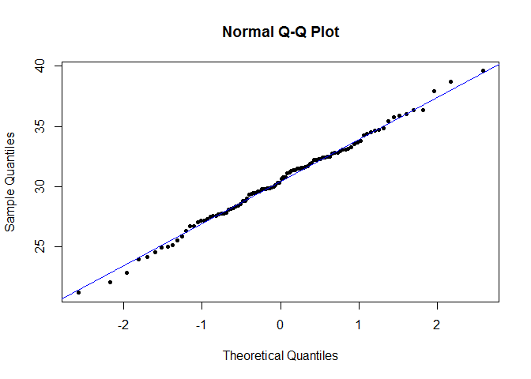

Em seguida para o tratamento com **metade da dose atualmente aplicada** (*nível 2*):

```r
base %>%
  filter(ind == 2) %>%
  pull(pesos) %>%
  shapiro.test()
```

```
##
##  Shapiro-Wilk normality test
##
## data:  .
## W = 0.97431, p-value = 0.04763
```

Com o p-valor de `0.048` rejeitamos a hipótese de normalidade dos dados para o tratamento do nível 2.

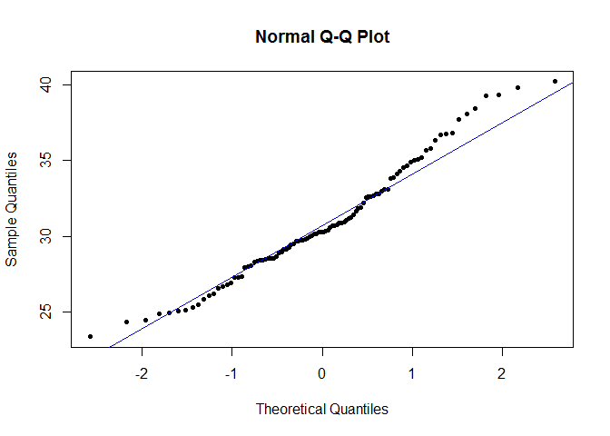

Por fim, para o tratamento com a **dose atualmente aplicada** (*nível 3*)

```r
base %>%
  filter(ind == 3) %>%
  pull(pesos) %>%
  shapiro.test()
```

```
##
##  Shapiro-Wilk normality test
##
## data:  .
## W = 0.98893, p-value = 0.5793
```

Com o p-valor de `0.579` não rejeitamos a hipótese de normalidade dos dados para o tratamento do nível 3.

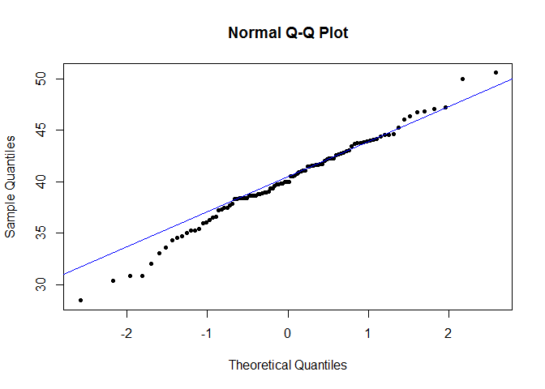

Com essa configuração, ao nível de significância estatística de 5 %, que a hipótese de normalidade da ANOVA foi violada. Logo, precisamos de uma abordagem não paramétrica para o experimento.

#### Teste de kruskal

Verificamos se os níveis representados, possuiem a mesma distribuição (hipótese nula). O teste de Kruskal é uma extensão do teste de Wilcoxon, que seá também utilizado na análise.

O teste de Kruskal-Wallis é o análogo ao teste F utilizado na ANOVA 1 fator. Enquanto a análise de variância dos testes dependem da hipótese de que todas as populações em confronto são independentes e normalmente distribuídas, o teste de Kruskal-Wallis não coloca nenhuma restrição sobre a comparação. Suponha que os dados provenham de k amostras aleatórias independentes com tamanhos amostrais $n_1, n_2, \dots, n_k$ sendo $N = n_1 + n_2 + \dots + n_k$ o número total de elementos considerados em todas as amostras.

Considerando as seguintes hipóteses:

$$\begin{cases}
H_{0}: \tau_1 = \tau_2 = \dots = \tau_n \\
H_{1}: \tau_1,\tau_2,\dots,\tau_n \mbox{ pelo menos um difere}
\end{cases}$$

```r
kruskal.test(pesos~ind, data = base)
```

```
##
##  Kruskal-Wallis rank sum test
##
## data:  pesos by ind
## Kruskal-Wallis chi-squared = 161.3, df = 2, p-value < 2.2e-16
```

com o p-valor de muito a baixo do nível de significância, rejeitamos a hipótese nula (distribuições iguais) para o teste de Kruskal. Em seguida, o teste de wilcox par-a-par.

Comparando o **nível 1** (sem agrotóxico) e o **nível 2** (metade da dose aplicada):

```r
wilcox.test(base$pesos[base$ind == 1], base$pesos[base$ind == 2])
```

```
##
##  Wilcoxon rank sum test with continuity correction
##
## data:  base$pesos[base$ind == 1] and base$pesos[base$ind == 2]
## W = 4861, p-value = 0.7351
## alternative hypothesis: true location shift is not equal to 0
```

Vemos que as distribuições não diferem.

Comparando o **nível 1** (sem agrotóxico) e o **nível 3** (dose total aplicada):

```r
wilcox.test(base$pesos[base$ind == 1], base$pesos[base$ind == 3])
```

```
##
##  Wilcoxon rank sum test with continuity correction
##
## data:  base$pesos[base$ind == 1] and base$pesos[base$ind == 3]
## W = 426, p-value < 2.2e-16
## alternative hypothesis: true location shift is not equal to 0
```

As distribuições diferem.

Comparando o **nível 2** (metade da dose aplicada) e o **nível 3** (dose total aplicada):

```r
wilcox.test(base$pesos[base$ind == 2], base$pesos[base$ind == 3])
```

```
##
##  Wilcoxon rank sum test with continuity correction
##
## data:  base$pesos[base$ind == 2] and base$pesos[base$ind == 3]
## W = 582, p-value < 2.2e-16
## alternative hypothesis: true location shift is not equal to 0
```

As distribuições diferem.

## Conclusão

Então temos diferença significativa entre os grupos 1 e 3 e entre 2 e 3. Então podemos dizer que há diferença significativa do peso das laranjas com dose atualmente aplicada de agrotóxicos, em relação às laranjas sem agrotóxicose com a metade da dose atualmente aplicada.